# (Ford GoBike)

## by (Shireen Talaat Mohammed Zayed)

## Preliminary Wrangling

FordGoBike data has a size of (183412 x 16) that provides infomation about bike trips during Feb. 2019. Each trip is anonymized and includes:

- Trip Duration (seconds)
- Start Time and Date
- End Time and Date
- Start Station ID
- Start Station Name
- Start Station Latitude
- Start Station Longitude
- End Station ID
- End Station Name
- End Station Latitude
- End Station Longitude
- Bike ID
- User Type (Subscriber or Customer – “Subscriber” = Member or “Customer” = Casual)

```python
# import all packages and set plots to be embedded inline
import numpy as np
import pandas as pd
import matplotlib.pyplot as plt
import seaborn as sb
import time
import datetime
import calendar
import random

%matplotlib inline
```

> Load in your dataset and describe its properties through the questions below. Try and motivate your exploration goals through this section.

```python
# load in the dataset into a pandas dataframe
df = pd.read_csv('201902-fordgobike-tripdata.csv')
df.head()
```

|  | duration_sec | start_time | end_time | start_station_id | start_station_name | start_station_latitude | start_station_longitude | end_station_id | end_station_name | end_station_latitude | end_station_longitude | bike_id | user_type | member_birth_year | member_gender | bike_share_for_all_trip |
| --- | --- | --- | --- | --- | --- | --- | --- | --- | --- | --- | --- | --- | --- | --- | --- | --- |
| 0 | 52185 | 2019-02-28 17:32:10.1450 | 2019-03-01 08:01:55.9750 | 21.0 | Montgomery St BART Station (Market St at 2nd St) | 37.789625 | -122.400811 | 13.0 | Commercial St at Montgomery St | 37.794231 | -122.402923 | 4902 | Customer | 1984.0 | Male | No |
| 1 | 42521 | 2019-02-28 18:53:21.7890 | 2019-03-01 06:42:03.0560 | 23.0 | The Embarcadero at Steuart St | 37.791464 | -122.391034 | 81.0 | Berry St at 4th St | 37.775880 | -122.393170 | 2535 | Customer | NaN | NaN | No |
| 2 | 61854 | 2019-02-28 12:13:13.2180 | 2019-03-01 05:24:08.1460 | 86.0 | Market St at Dolores St | 37.769305 | -122.426826 | 3.0 | Powell St BART Station (Market St at 4th St) | 37.786375 | -122.404904 | 5905 | Customer | 1972.0 | Male | No |
| 3 | 36490 | 2019-02-28 17:54:26.0100 | 2019-03-01 04:02:36.8420 | 375.0 | Grove St at Masonic Ave | 37.774836 | -122.446546 | 70.0 | Central Ave at Fell St | 37.773311 | -122.444293 | 6638 | Subscriber | 1989.0 | Other | No |
| 4 | 1585 | 2019-02-28 23:54:18.5490 | 2019-03-01 00:20:44.0740 | 7.0 | Frank H Ogawa Plaza | 37.804562 | -122.271738 | 222.0 | 10th Ave at E 15th St | 37.792714 | -122.248780 | 4898 | Subscriber | 1974.0 | Male | Yes |

```python
# high-level overview of data shape and composition
print(df.shape)
print(df.dtypes)
```

```
(183412, 16)
duration_sec                 int64
start_time                  object
end_time                    object
start_station_id           float64
start_station_name          object
start_station_latitude     float64
start_station_longitude    float64
end_station_id             float64
end_station_name            object
end_station_latitude       float64
end_station_longitude      float64
bike_id                      int64
user_type                   object
member_birth_year          float64
member_gender               object
bike_share_for_all_trip     object
dtype: object
```

```python
df.info()
```

```
<class 'pandas.core.frame.DataFrame'>
RangeIndex: 183412 entries, 0 to 183411
Data columns (total 16 columns):
 #   Column                   Non-Null Count   Dtype
---  ------                   --------------   -----
 0   duration_sec             183412 non-null  int64
 1   start_time               183412 non-null  object
 2   end_time                 183412 non-null  object
 3   start_station_id         183215 non-null  float64
 4   start_station_name       183215 non-null  object
 5   start_station_latitude   183412 non-null  float64
 6   start_station_longitude  183412 non-null  float64
 7   end_station_id           183215 non-null  float64
 8   end_station_name         183215 non-null  object
 9   end_station_latitude     183412 non-null  float64
 10  end_station_longitude    183412 non-null  float64
 11  bike_id                  183412 non-null  int64
 12  user_type                183412 non-null  object
 13  member_birth_year        175147 non-null  float64
 14  member_gender            175147 non-null  object
 15  bike_share_for_all_trip  183412 non-null  object
dtypes: float64(7), int64(2), object(7)
memory usage: 22.4+ MB
```

```python
# view missing value count for each feature in twitter archive
df.isnull().sum()
```

```
duration_sec                  0
start_time                    0
end_time                      0
start_station_id            197
start_station_name          197
start_station_latitude        0
start_station_longitude       0
end_station_id              197
end_station_name            197
end_station_latitude          0
end_station_longitude         0
bike_id                       0
user_type                     0
member_birth_year          8265
member_gender              8265
bike_share_for_all_trip       0
dtype: int64
```

```python
# Check for duplicates
df.duplicated().sum()
```

```
0
```

```python
# check some dataframe statistics
df.describe()
```

|  | duration_sec | start_station_id | start_station_latitude | start_station_longitude | end_station_id | end_station_latitude | end_station_longitude | bike_id | member_birth_year |
| --- | --- | --- | --- | --- | --- | --- | --- | --- | --- |
| count | 183412.000000 | 183215.000000 | 183412.000000 | 183412.000000 | 183215.000000 | 183412.000000 | 183412.000000 | 183412.000000 | 175147.000000 |
| mean | 726.078435 | 138.590427 | 37.771223 | -122.352664 | 136.249123 | 37.771427 | -122.352250 | 4472.906375 | 1984.806437 |
| std | 1794.389780 | 111.778864 | 0.099581 | 0.117097 | 111.515131 | 0.099490 | 0.116673 | 1664.383394 | 10.116689 |
| min | 61.000000 | 3.000000 | 37.317298 | -122.453704 | 3.000000 | 37.317298 | -122.453704 | 11.000000 | 1878.000000 |
| 25% | 325.000000 | 47.000000 | 37.770083 | -122.412408 | 44.000000 | 37.770407 | -122.411726 | 3777.000000 | 1980.000000 |
| 50% | 514.000000 | 104.000000 | 37.780760 | -122.398285 | 100.000000 | 37.781010 | -122.398279 | 4958.000000 | 1987.000000 |
| 75% | 796.000000 | 239.000000 | 37.797280 | -122.286533 | 235.000000 | 37.797320 | -122.288045 | 5502.000000 | 1992.000000 |
| max | 85444.000000 | 398.000000 | 37.880222 | -121.874119 | 398.000000 | 37.880222 | -121.874119 | 6645.000000 | 2001.000000 |

```python
# arrange the dataframe by date to check the duration
df.sort_values(by=['start_time'], inplace=True, ascending=False)
df.head()
```

|  | duration_sec | start_time | end_time | start_station_id | start_station_name | start_station_latitude | start_station_longitude | end_station_id | end_station_name | end_station_latitude | end_station_longitude | bike_id | user_type | member_birth_year | member_gender | bike_share_for_all_trip |
| --- | --- | --- | --- | --- | --- | --- | --- | --- | --- | --- | --- | --- | --- | --- | --- | --- |
| 15 | 208 | 2019-02-28 23:59:18.5480 | 2019-03-01 00:02:47.2280 | 349.0 | Howard St at Mary St | 37.781010 | -122.405666 | 60.0 | 8th St at Ringold St | 37.774520 | -122.409449 | 6361 | Subscriber | 1993.0 | Male | Yes |
| 10 | 458 | 2019-02-28 23:57:57.2110 | 2019-03-01 00:05:35.4350 | 370.0 | Jones St at Post St | 37.787327 | -122.413278 | 43.0 | San Francisco Public Library (Grove St at Hyde... | 37.778768 | -122.415929 | 5318 | Subscriber | 1996.0 | Female | Yes |
| 11 | 506 | 2019-02-28 23:56:55.5400 | 2019-03-01 00:05:21.7330 | 44.0 | Civic Center/UN Plaza BART Station (Market St ... | 37.781074 | -122.411738 | 343.0 | Bryant St at 2nd St | 37.783172 | -122.393572 | 5848 | Subscriber | 1993.0 | Male | No |
| 14 | 395 | 2019-02-28 23:56:26.8480 | 2019-03-01 00:03:01.9470 | 243.0 | Bancroft Way at College Ave | 37.869360 | -122.254337 | 252.0 | Channing Way at Shattuck Ave | 37.865847 | -122.267443 | 4786 | Subscriber | 1988.0 | Male | No |
| 6 | 1147 | 2019-02-28 23:55:35.1040 | 2019-03-01 00:14:42.5880 | 300.0 | Palm St at Willow St | 37.317298 | -121.884995 | 312.0 | San Jose Diridon Station | 37.329732 | -121.901782 | 3803 | Subscriber | 1983.0 | Female | No |

```python
#check last itmes of the data frame
df.tail()
```

|  | duration_sec | start_time | end_time | start_station_id | start_station_name | start_station_latitude | start_station_longitude | end_station_id | end_station_name | end_station_latitude | end_station_longitude | bike_id | user_type | member_birth_year | member_gender | bike_share_for_all_trip |
| --- | --- | --- | --- | --- | --- | --- | --- | --- | --- | --- | --- | --- | --- | --- | --- | --- |
| 183408 | 313 | 2019-02-01 00:05:34.7440 | 2019-02-01 00:10:48.5020 | 21.0 | Montgomery St BART Station (Market St at 2nd St) | 37.789625 | -122.400811 | 66.0 | 3rd St at Townsend St | 37.778742 | -122.392741 | 4960 | Subscriber | 1984.0 | Male | No |
| 183410 | 139 | 2019-02-01 00:05:34.3600 | 2019-02-01 00:07:54.2870 | 220.0 | San Pablo Ave at MLK Jr Way | 37.811351 | -122.273422 | 216.0 | San Pablo Ave at 27th St | 37.817827 | -122.275698 | 5095 | Subscriber | 1988.0 | Male | No |
| 183407 | 480 | 2019-02-01 00:04:49.7240 | 2019-02-01 00:12:50.0340 | 27.0 | Beale St at Harrison St | 37.788059 | -122.391865 | 324.0 | Union Square (Powell St at Post St) | 37.788300 | -122.408531 | 4832 | Subscriber | 1996.0 | Male | No |
| 183406 | 706 | 2019-02-01 00:04:40.6160 | 2019-02-01 00:16:27.0800 | 138.0 | Jersey St at Church St | 37.750900 | -122.427411 | 78.0 | Folsom St at 9th St | 37.773717 | -122.411647 | 5017 | Subscriber | 1988.0 | Male | No |
| 183411 | 271 | 2019-02-01 00:00:20.6360 | 2019-02-01 00:04:52.0580 | 24.0 | Spear St at Folsom St | 37.789677 | -122.390428 | 37.0 | 2nd St at Folsom St | 37.785000 | -122.395936 | 1057 | Subscriber | 1989.0 | Male | No |

# Observations

### After assessing the DataFrames I found some issues to clean and fix

- start_time and end_time are objects and should be converted into pandas Datetime.
- member_birth_year is float and should be converted into int.
- user_type, member_gender, and bike_share_for_all_trip will be converted into category.
- start_station_id , end_station_id, and bike_id should be converted into to object format.
- remove member_birth_year before 1960.
- duration _min will be add because duration_sec colomn does not make sense.
- add age colomn

```python
# creat new dataframe to be cleaned
df_new = df.copy()
```

#### Define:

- start_time and end_time are objects and should be converted into pandas Datetime
- user_type, member_gender, and bike_share_for_all_trip will be converted into category.
- start_station_id , end_station_id, and bike_id should be converted into to object format
- member_birth_year is float and should be converted into int.

#### Code

```python
df_new[['start_time','end_time']]= df_new[['start_time','end_time']].apply(pd.to_datetime, format='%Y-%m-%d %H:%M:%S.%f')
```

```python
df_new[['user_type', 'member_gender','bike_share_for_all_trip' ]]= df_new[['user_type', 'member_gender','bike_share_for_all_trip']].astype('category')
```

```python
df_new[['start_station_id' , 'end_station_id', 'bike_id']] = df_new[['start_station_id' , 'end_station_id', 'bike_id']].astype('str')
```

```python
# fill all nan values with mean then convert type from float to int
df_new['member_birth_year'].fillna(df_new['member_birth_year'].mean(), inplace=True)
df_new['member_birth_year'] = df_new['member_birth_year'].astype('int')
```

#### Test

```python
df_new.info()
```

```
<class 'pandas.core.frame.DataFrame'>
Int64Index: 183412 entries, 15 to 183411
Data columns (total 16 columns):
 #   Column                   Non-Null Count   Dtype
---  ------                   --------------   -----
 0   duration_sec             183412 non-null  int64
 1   start_time               183412 non-null  datetime64[ns]
 2   end_time                 183412 non-null  datetime64[ns]
 3   start_station_id         183412 non-null  object
 4   start_station_name       183215 non-null  object
 5   start_station_latitude   183412 non-null  float64
 6   start_station_longitude  183412 non-null  float64
 7   end_station_id           183412 non-null  object
 8   end_station_name         183215 non-null  object
 9   end_station_latitude     183412 non-null  float64
 10  end_station_longitude    183412 non-null  float64
 11  bike_id                  183412 non-null  object
 12  user_type                183412 non-null  category
 13  member_birth_year        183412 non-null  int32
 14  member_gender            175147 non-null  category
 15  bike_share_for_all_trip  183412 non-null  category
dtypes: category(3), datetime64[ns](2), float64(4), int32(1), int64(1), object(5)
memory usage: 19.4+ MB
```

```python
df_new.head()
```

|  | duration_sec | start_time | end_time | start_station_id | start_station_name | start_station_latitude | start_station_longitude | end_station_id | end_station_name | end_station_latitude | end_station_longitude | bike_id | user_type | member_birth_year | member_gender | bike_share_for_all_trip |
| --- | --- | --- | --- | --- | --- | --- | --- | --- | --- | --- | --- | --- | --- | --- | --- | --- |
| 15 | 208 | 2019-02-28 23:59:18.548 | 2019-03-01 00:02:47.228 | 349.0 | Howard St at Mary St | 37.781010 | -122.405666 | 60.0 | 8th St at Ringold St | 37.774520 | -122.409449 | 6361 | Subscriber | 1993 | Male | Yes |
| 10 | 458 | 2019-02-28 23:57:57.211 | 2019-03-01 00:05:35.435 | 370.0 | Jones St at Post St | 37.787327 | -122.413278 | 43.0 | San Francisco Public Library (Grove St at Hyde... | 37.778768 | -122.415929 | 5318 | Subscriber | 1996 | Female | Yes |
| 11 | 506 | 2019-02-28 23:56:55.540 | 2019-03-01 00:05:21.733 | 44.0 | Civic Center/UN Plaza BART Station (Market St ... | 37.781074 | -122.411738 | 343.0 | Bryant St at 2nd St | 37.783172 | -122.393572 | 5848 | Subscriber | 1993 | Male | No |
| 14 | 395 | 2019-02-28 23:56:26.848 | 2019-03-01 00:03:01.947 | 243.0 | Bancroft Way at College Ave | 37.869360 | -122.254337 | 252.0 | Channing Way at Shattuck Ave | 37.865847 | -122.267443 | 4786 | Subscriber | 1988 | Male | No |
| 6 | 1147 | 2019-02-28 23:55:35.104 | 2019-03-01 00:14:42.588 | 300.0 | Palm St at Willow St | 37.317298 | -121.884995 | 312.0 | San Jose Diridon Station | 37.329732 | -121.901782 | 3803 | Subscriber | 1983 | Female | No |

#### Define:

- add duration _min colomn
- remove member_birth_year before 1960.
- add age colomn

#### Code

```python
# add duration_min to be easier to unerstand
df_new['duration_min'] = (df_new['duration_sec']/60).astype(float)
```

```python
#remove member_birth_year before 1960
df_new.drop(df_new[df_new.member_birth_year < 1960].index, inplace=True)
```

```python
# add age colomn
from datetime import datetime
from datetime import date
now = pd.to_datetime('now')
df_new['member_age'] = now.year - df['member_birth_year']
df_new['member_age'].fillna((df_new['member_age'].mean()), inplace=True)
df_new['member_age'] = df_new['member_age'].astype('int')
```

#### Test

```python
df_new.info()
```

[output not shown]

```python
df_new.head()
```

|  | duration_sec | start_time | end_time | start_station_id | start_station_name | start_station_latitude | start_station_longitude | end_station_id | end_station_name | end_station_latitude | end_station_longitude | bike_id | user_type | member_birth_year | member_gender | bike_share_for_all_trip | duration_min | age | member_age |
| --- | --- | --- | --- | --- | --- | --- | --- | --- | --- | --- | --- | --- | --- | --- | --- | --- | --- | --- | --- |
| 15 | 208 | 2019-02-28 23:59:18.548 | 2019-03-01 00:02:47.228 | 349.0 | Howard St at Mary St | 37.781010 | -122.405666 | 60.0 | 8th St at Ringold St | 37.774520 | -122.409449 | 6361 | Subscriber | 1993 | Male | Yes | 3.466667 | 28.0 | 28 |
| 10 | 458 | 2019-02-28 23:57:57.211 | 2019-03-01 00:05:35.435 | 370.0 | Jones St at Post St | 37.787327 | -122.413278 | 43.0 | San Francisco Public Library (Grove St at Hyde... | 37.778768 | -122.415929 | 5318 | Subscriber | 1996 | Female | Yes | 7.633333 | 25.0 | 25 |
| 11 | 506 | 2019-02-28 23:56:55.540 | 2019-03-01 00:05:21.733 | 44.0 | Civic Center/UN Plaza BART Station (Market St ... | 37.781074 | -122.411738 | 343.0 | Bryant St at 2nd St | 37.783172 | -122.393572 | 5848 | Subscriber | 1993 | Male | No | 8.433333 | 28.0 | 28 |
| 14 | 395 | 2019-02-28 23:56:26.848 | 2019-03-01 00:03:01.947 | 243.0 | Bancroft Way at College Ave | 37.869360 | -122.254337 | 252.0 | Channing Way at Shattuck Ave | 37.865847 | -122.267443 | 4786 | Subscriber | 1988 | Male | No | 6.583333 | 33.0 | 33 |
| 6 | 1147 | 2019-02-28 23:55:35.104 | 2019-03-01 00:14:42.588 | 300.0 | Palm St at Willow St | 37.317298 | -121.884995 | 312.0 | San Jose Diridon Station | 37.329732 | -121.901782 | 3803 | Subscriber | 1983 | Female | No | 19.116667 | 38.0 | 38 |

```python
df_new.describe()
```

[output not shown]

### What is the structure of your dataset?

FordGoBike data has a size of (183412 x 16) that provides infomation about bike trips during Feb. 2019. Each trip is anonymized and includes:

Trip Duration (seconds) Start Time and Date End Time and Date Start Station ID Start Station Name Start Station Latitude Start Station Longitude End Station ID End Station Name End Station Latitude End Station Longitude Bike ID User Type (Subscriber or Customer – “Subscriber” = Member or “Customer” = Casual)

### What is/are the main feature(s) of interest in your dataset?

I'm most interested in figuring out the average duration of trips, most common station, which gender, and what age uses the bikes more, and what day includes the highest bike rent. Therefore we can provide this right station with more appropriate bikes that suit the usage purpose.

### What features in the dataset do you think will help support your investigation into your feature(s) of interest?

I expect that Start Time and Date End Time and Date will help understanding trip duration and days with highest bike demand. In addition Start Station Name and End Station Name will be beneficial in getting most common sations. Finally Member Gender, and age will be helpful in this research.

## Univariate Exploration

> In this section, investigate distributions of individual variables. If you see unusual points or outliers, take a deeper look to clean things up and prepare yourself to look at relationships between variables.

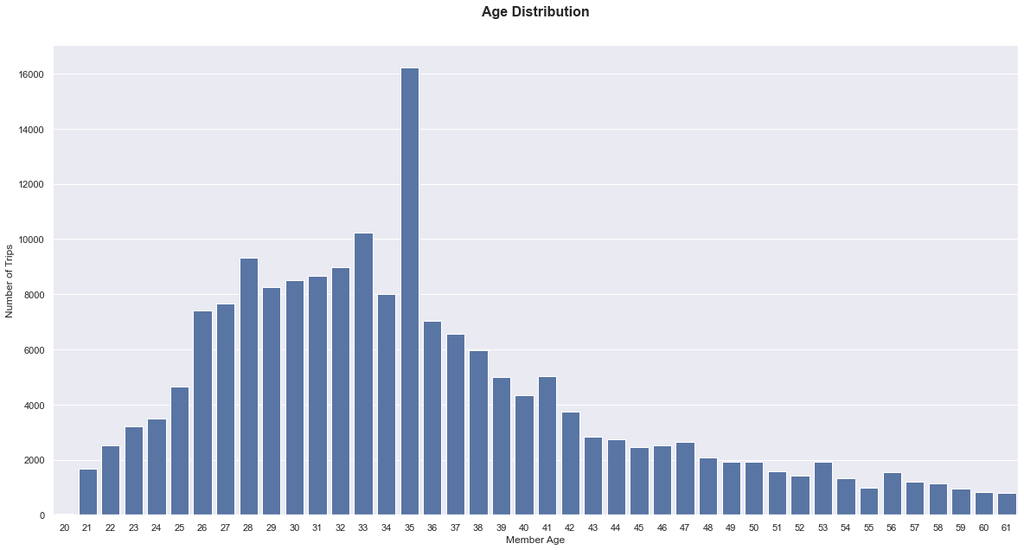

```python
# Ploting age ditribution
base_color = sb.color_palette()[0]
sb.countplot(data = df_new, x  = 'member_age', color = base_color);
sb.set(rc={'figure.figsize':(40,10)})
plt.title('Age Distribution', y=1.05, fontsize=16, fontweight='bold')
plt.xlabel('Member Age')
plt.ylabel('Number of Trips');
```

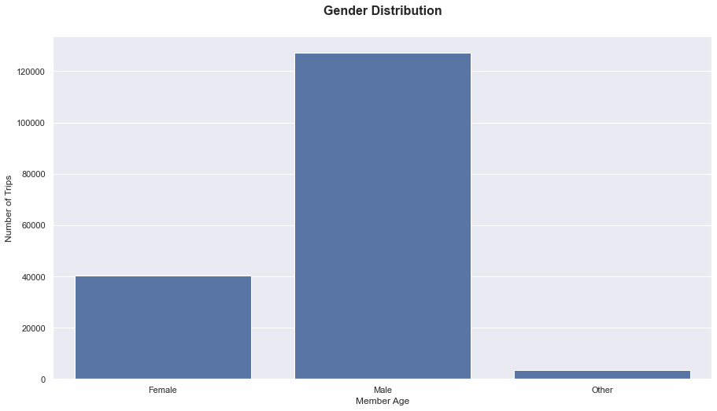

```python
# Ploting gender ditribution
base_color = sb.color_palette()[0]
sb.countplot(data = df_new, x  = 'member_gender', color = base_color);
sb.set(rc={'figure.figsize':(20,8)})
plt.title('Gender Distribution', y=1.05, fontsize=16, fontweight='bold')
plt.xlabel('Member Age')
plt.ylabel('Number of Trips');
```

#### Male members are more than other genders.

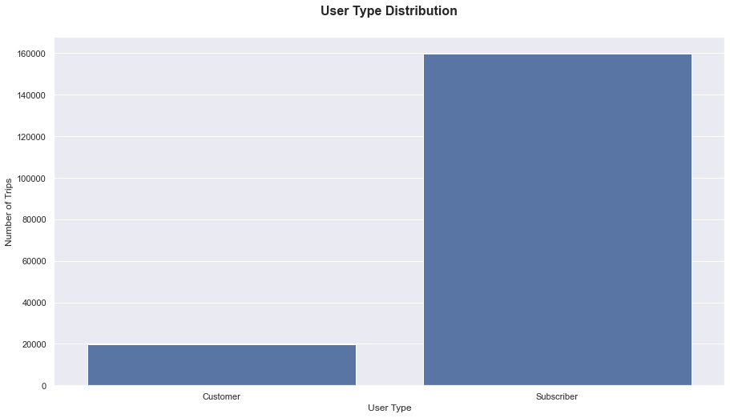

```python
sb.countplot(data=df_new, x='user_type', color=base_color);
sb.set(rc={'figure.figsize':(20,8)})
plt.title('User Type Distribution', y=1.05, fontsize=16, fontweight='bold')
plt.xlabel('User Type')
plt.ylabel('Number of Trips');
```

#### Subscribers are more than customers.

```python
df_new['day']=df_new['start_time'].dt.strftime('%A')
```

```python
df_new['day'] = df_new['day'].astype('category')
```

```python
df_new.head()
```

|  | duration_sec | start_time | end_time | start_station_id | start_station_name | start_station_latitude | start_station_longitude | end_station_id | end_station_name | end_station_latitude | end_station_longitude | bike_id | user_type | member_birth_year | member_gender | bike_share_for_all_trip | duration_min | age | member_age | day |
| --- | --- | --- | --- | --- | --- | --- | --- | --- | --- | --- | --- | --- | --- | --- | --- | --- | --- | --- | --- | --- |
| 15 | 208 | 2019-02-28 23:59:18.548 | 2019-03-01 00:02:47.228 | 349.0 | Howard St at Mary St | 37.781010 | -122.405666 | 60.0 | 8th St at Ringold St | 37.774520 | -122.409449 | 6361 | Subscriber | 1993 | Male | Yes | 3.466667 | 28.0 | 28 | Thursday |
| 10 | 458 | 2019-02-28 23:57:57.211 | 2019-03-01 00:05:35.435 | 370.0 | Jones St at Post St | 37.787327 | -122.413278 | 43.0 | San Francisco Public Library (Grove St at Hyde... | 37.778768 | -122.415929 | 5318 | Subscriber | 1996 | Female | Yes | 7.633333 | 25.0 | 25 | Thursday |
| 11 | 506 | 2019-02-28 23:56:55.540 | 2019-03-01 00:05:21.733 | 44.0 | Civic Center/UN Plaza BART Station (Market St ... | 37.781074 | -122.411738 | 343.0 | Bryant St at 2nd St | 37.783172 | -122.393572 | 5848 | Subscriber | 1993 | Male | No | 8.433333 | 28.0 | 28 | Thursday |
| 14 | 395 | 2019-02-28 23:56:26.848 | 2019-03-01 00:03:01.947 | 243.0 | Bancroft Way at College Ave | 37.869360 | -122.254337 | 252.0 | Channing Way at Shattuck Ave | 37.865847 | -122.267443 | 4786 | Subscriber | 1988 | Male | No | 6.583333 | 33.0 | 33 | Thursday |
| 6 | 1147 | 2019-02-28 23:55:35.104 | 2019-03-01 00:14:42.588 | 300.0 | Palm St at Willow St | 37.317298 | -121.884995 | 312.0 | San Jose Diridon Station | 37.329732 | -121.901782 | 3803 | Subscriber | 1983 | Female | No | 19.116667 | 38.0 | 38 | Thursday |

```python
df_new.info()
```

```
<class 'pandas.core.frame.DataFrame'>
Int64Index: 179258 entries, 15 to 183411
Data columns (total 20 columns):
 #   Column                   Non-Null Count   Dtype
---  ------                   --------------   -----
 0   duration_sec             179258 non-null  int64
 1   start_time               179258 non-null  datetime64[ns]
 2   end_time                 179258 non-null  datetime64[ns]
 3   start_station_id         179258 non-null  object
 4   start_station_name       179061 non-null  object
 5   start_station_latitude   179258 non-null  float64
 6   start_station_longitude  179258 non-null  float64
 7   end_station_id           179258 non-null  object
 8   end_station_name         179061 non-null  object
 9   end_station_latitude     179258 non-null  float64
 10  end_station_longitude    179258 non-null  float64
 11  bike_id                  179258 non-null  object
 12  user_type                179258 non-null  category
 13  member_birth_year        179258 non-null  int32
 14  member_gender            170993 non-null  category
 15  bike_share_for_all_trip  179258 non-null  category
 16  duration_min             179258 non-null  float64
 17  age                      170993 non-null  float64
 18  member_age               179258 non-null  int32
 19  day                      179258 non-null  category
dtypes: category(4), datetime64[ns](2), float64(6), int32(2), int64(1), object(5)
memory usage: 27.6+ MB
```

```python
weekday = ['Monday', 'Tuesday', 'Wednesday', 'Thursday', 'Friday', 'Saturday', 'Sunday']
day_order = pd.api.types.CategoricalDtype(ordered=True, categories=weekday)
df_new['day'] = df_new['day'].astype(day_order)
df_new
```

|  | duration_sec | start_time | end_time | start_station_id | start_station_name | start_station_latitude | start_station_longitude | end_station_id | end_station_name | end_station_latitude | end_station_longitude | bike_id | user_type | member_birth_year | member_gender | bike_share_for_all_trip | duration_min | age | member_age | day |
| --- | --- | --- | --- | --- | --- | --- | --- | --- | --- | --- | --- | --- | --- | --- | --- | --- | --- | --- | --- | --- |
| 15 | 208 | 2019-02-28 23:59:18.548 | 2019-03-01 00:02:47.228 | 349.0 | Howard St at Mary St | 37.781010 | -122.405666 | 60.0 | 8th St at Ringold St | 37.774520 | -122.409449 | 6361 | Subscriber | 1993 | Male | Yes | 3.466667 | 28.0 | 28 | Thursday |
| 10 | 458 | 2019-02-28 23:57:57.211 | 2019-03-01 00:05:35.435 | 370.0 | Jones St at Post St | 37.787327 | -122.413278 | 43.0 | San Francisco Public Library (Grove St at Hyde... | 37.778768 | -122.415929 | 5318 | Subscriber | 1996 | Female | Yes | 7.633333 | 25.0 | 25 | Thursday |
| 11 | 506 | 2019-02-28 23:56:55.540 | 2019-03-01 00:05:21.733 | 44.0 | Civic Center/UN Plaza BART Station (Market St ... | 37.781074 | -122.411738 | 343.0 | Bryant St at 2nd St | 37.783172 | -122.393572 | 5848 | Subscriber | 1993 | Male | No | 8.433333 | 28.0 | 28 | Thursday |
| 14 | 395 | 2019-02-28 23:56:26.848 | 2019-03-01 00:03:01.947 | 243.0 | Bancroft Way at College Ave | 37.869360 | -122.254337 | 252.0 | Channing Way at Shattuck Ave | 37.865847 | -122.267443 | 4786 | Subscriber | 1988 | Male | No | 6.583333 | 33.0 | 33 | Thursday |
| 6 | 1147 | 2019-02-28 23:55:35.104 | 2019-03-01 00:14:42.588 | 300.0 | Palm St at Willow St | 37.317298 | -121.884995 | 312.0 | San Jose Diridon Station | 37.329732 | -121.901782 | 3803 | Subscriber | 1983 | Female | No | 19.116667 | 38.0 | 38 | Thursday |
| ... | ... | ... | ... | ... | ... | ... | ... | ... | ... | ... | ... | ... | ... | ... | ... | ... | ... | ... | ... | ... |
| 183408 | 313 | 2019-02-01 00:05:34.744 | 2019-02-01 00:10:48.502 | 21.0 | Montgomery St BART Station (Market St at 2nd St) | 37.789625 | -122.400811 | 66.0 | 3rd St at Townsend St | 37.778742 | -122.392741 | 4960 | Subscriber | 1984 | Male | No | 5.216667 | 37.0 | 37 | Friday |
| 183410 | 139 | 2019-02-01 00:05:34.360 | 2019-02-01 00:07:54.287 | 220.0 | San Pablo Ave at MLK Jr Way | 37.811351 | -122.273422 | 216.0 | San Pablo Ave at 27th St | 37.817827 | -122.275698 | 5095 | Subscriber | 1988 | Male | No | 2.316667 | 33.0 | 33 | Friday |
| 183407 | 480 | 2019-02-01 00:04:49.724 | 2019-02-01 00:12:50.034 | 27.0 | Beale St at Harrison St | 37.788059 | -122.391865 | 324.0 | Union Square (Powell St at Post St) | 37.788300 | -122.408531 | 4832 | Subscriber | 1996 | Male | No | 8.000000 | 25.0 | 25 | Friday |
| 183406 | 706 | 2019-02-01 00:04:40.616 | 2019-02-01 00:16:27.080 | 138.0 | Jersey St at Church St | 37.750900 | -122.427411 | 78.0 | Folsom St at 9th St | 37.773717 | -122.411647 | 5017 | Subscriber | 1988 | Male | No | 11.766667 | 33.0 | 33 | Friday |
| 183411 | 271 | 2019-02-01 00:00:20.636 | 2019-02-01 00:04:52.058 | 24.0 | Spear St at Folsom St | 37.789677 | -122.390428 | 37.0 | 2nd St at Folsom St | 37.785000 | -122.395936 | 1057 | Subscriber | 1989 | Male | No | 4.516667 | 32.0 | 32 | Friday |

179258 rows × 20 columns

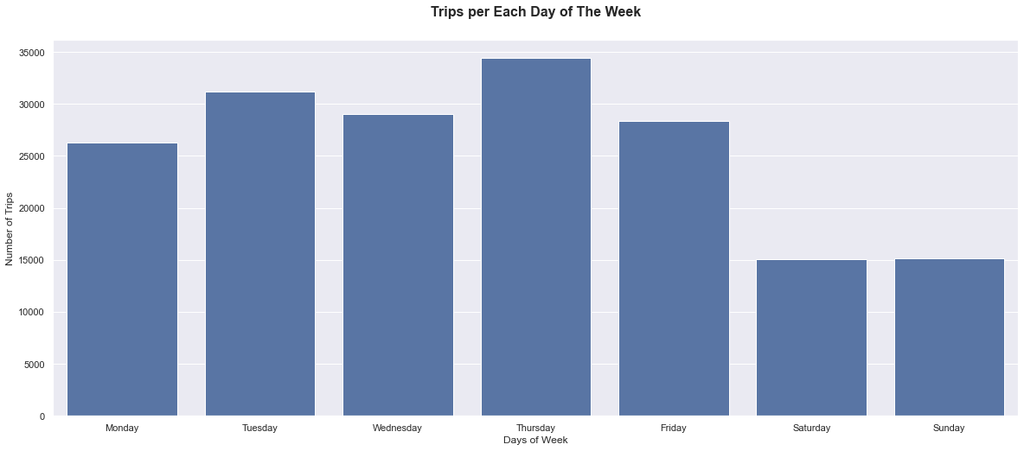

```python
#day_order = df_new['day'].value_counts().index
base_color = sb.color_palette()[0]
sb.countplot(data=df_new, x='day', color = base_color);
plt.xlabel('Days of Week');
plt.ylabel('Number of Trips');
plt.title('Trips per Each Day of The Week', y=1.05, fontsize=16, fontweight='bold');
```

#### The day with the most trips is Thursday. Weekends have the least trips.

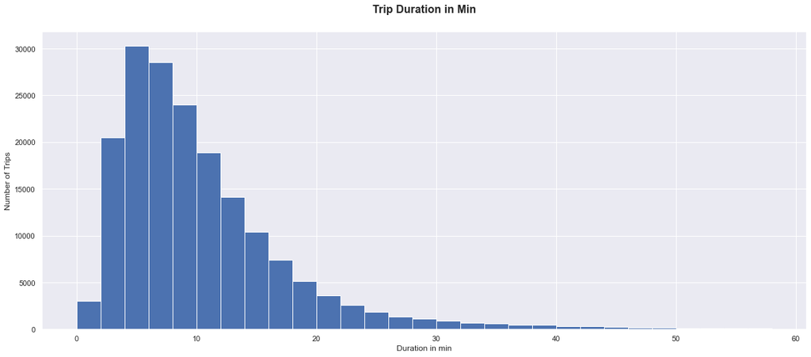

```python
bins = np.arange(0, 60, 2)

plt.hist(data = df_new, x = 'duration_min', bins = bins);
plt.xlabel('Duration in min');
plt.ylabel('Number of Trips');
plt.title('Trip Duration in Min', y=1.05, fontsize=16, fontweight='bold')
```

#### The average Trip Duration is between 6 and 12 mins.

```python
station_top_start = df_new['start_station_name'].value_counts(ascending = False)[:10]
station_top_start
```

```
Market St at 10th St                                         3879
San Francisco Caltrain Station 2  (Townsend St at 4th St)    3445
Berry St at 4th St                                           2970
Montgomery St BART Station (Market St at 2nd St)             2844
Powell St BART Station (Market St at 4th St)                 2701
San Francisco Ferry Building (Harry Bridges Plaza)           2621
San Francisco Caltrain (Townsend St at 4th St)               2600
Powell St BART Station (Market St at 5th St)                 2304
Howard St at Beale St                                        2243
Steuart St at Market St                                      2210
Name: start_station_name, dtype: int64
```

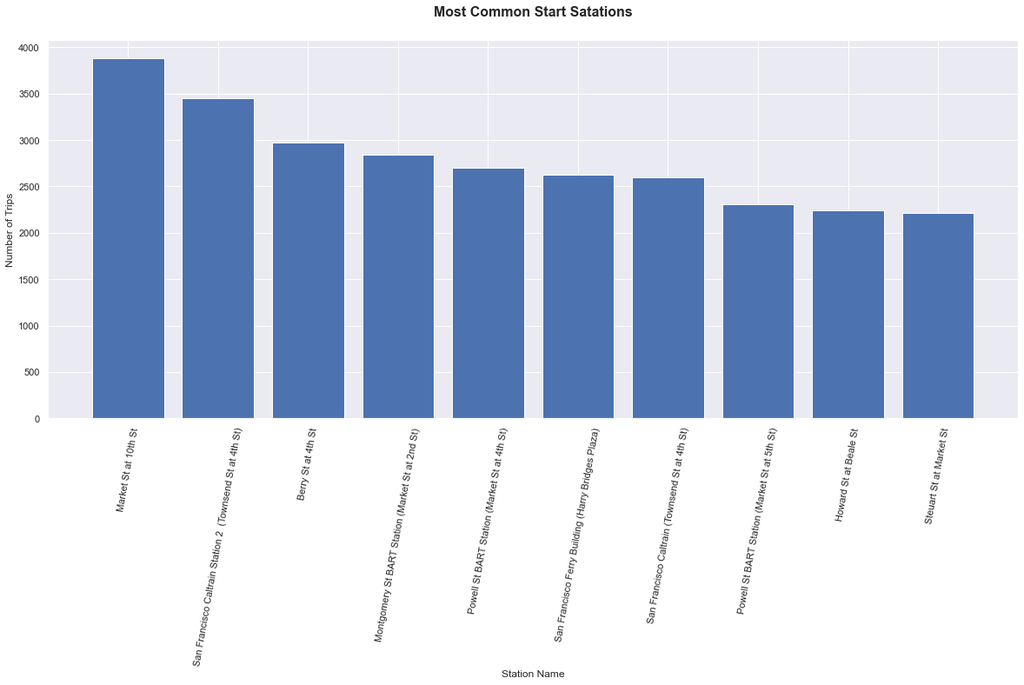

```python
plt.bar(x = station_top_start.index, height = station_top_start.values);
sb.set(rc={'figure.figsize':(20,10)})
plt.xlabel('Station Name')
plt.ylabel('Number of Trips');
plt.title('Most Common Start Satations', y=1.05, fontsize=16, fontweight='bold')
plt.xticks(rotation= 80);
```

```python
station_top_end = df_new['end_station_name'].value_counts(ascending = False)[:10]
station_top_end
```

```
San Francisco Caltrain Station 2  (Townsend St at 4th St)    4781
Market St at 10th St                                         3934
Montgomery St BART Station (Market St at 2nd St)             3577
San Francisco Ferry Building (Harry Bridges Plaza)           3243
Powell St BART Station (Market St at 4th St)                 2939
San Francisco Caltrain (Townsend St at 4th St)               2830
Berry St at 4th St                                           2806
The Embarcadero at Sansome St                                2450
Powell St BART Station (Market St at 5th St)                 2333
Steuart St at Market St                                      2296
Name: end_station_name, dtype: int64
```

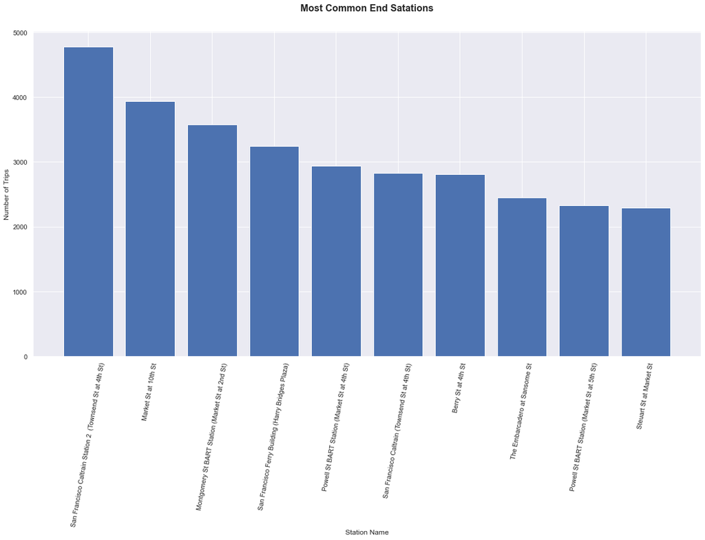

```python
plt.bar(x = station_top_end.index, height = station_top_end.values);
sb.set(rc={'figure.figsize':(20,10)})
plt.xlabel('Station Name')
plt.ylabel('Number of Trips');
plt.title('Most Common End Satations', y=1.05, fontsize=16, fontweight='bold')
plt.xticks(rotation= 80);
```

### Discuss the distribution(s) of your variable(s) of interest. Were there any unusual points? Did you need to perform any transformations?

variables of interest are:

- Duration
- Age
- Gender
- User Type
- Days of the week

Tansformations preformed are as follows:

- start_time and end_time are objects and should be converted into pandas Datetime.
- member_birth_year is float and should be converted into int.
- user_type, member_gender, and bike_share_for_all_trip will be converted into category.
- start_station_id , end_station_id, and bike_id should be converted into to object format.

## Bivariate Exploration

> In this section, investigate relationships between pairs of variables in your data. Make sure the variables that you cover here have been introduced in some fashion in the previous section (univariate exploration).

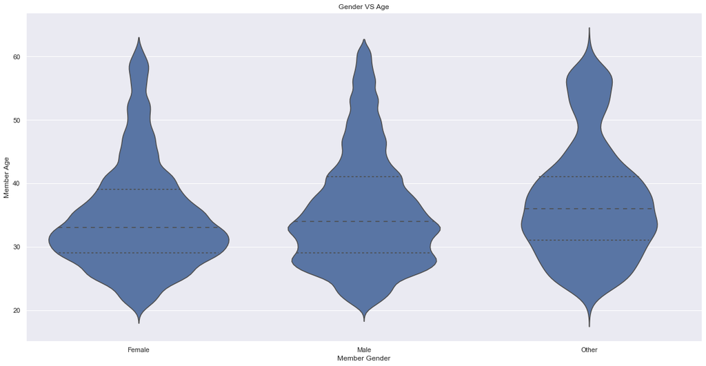

```python
base_color = sb.color_palette()[0]
sb.violinplot(data=df_new, x='member_gender', y='member_age', color=base_color, inner = 'quartile');
plt.xlabel('Member Gender')
plt.ylabel('Member Age');
plt.title('Gender VS Age');
```

#### Most Female age is between 28 : 38, however most male age is between 28: 42.

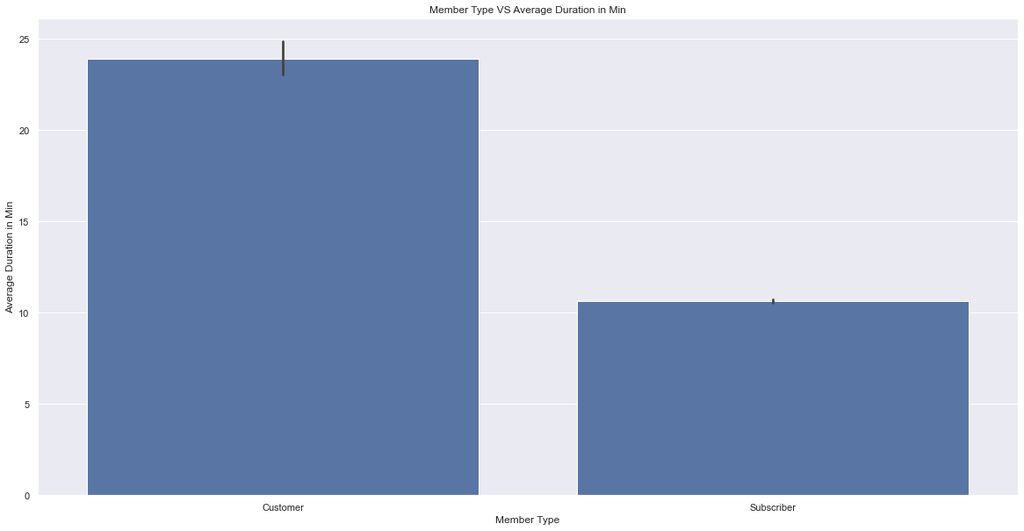

```python
base_color = sb.color_palette()[0]
sb.barplot(data=df_new, x='user_type', y='duration_min', color=base_color);
plt.xlabel('Member Type')
plt.ylabel('Average Duration in Min');
plt.title('Member Type VS Average Duration in Min');
```

#### It seems that customers have longer trips than subscribers

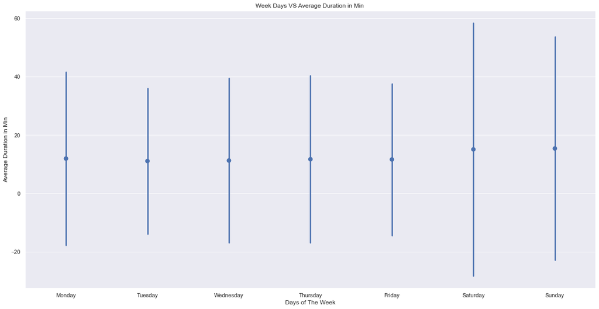

```python
base_color = sb.color_palette()[0]
sb.pointplot(data=df_new, x='day', y='duration_min', color=base_color, ci = 'sd', linestyles = "");
sb.set(rc={'figure.figsize':(20,8)})
plt.xlabel('Days of The Week')
plt.ylabel('Average Duration in Min');
plt.title('Week Days VS Average Duration in Min ');
```

#### Trip duration is longer on weekends than week days

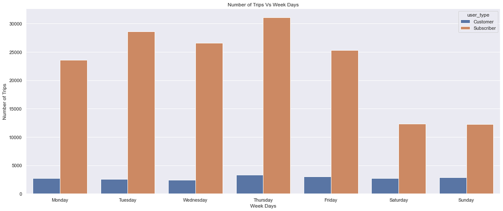

```python
sb.countplot(data=df_new, x='day', hue='user_type');
plt.xlabel('Week Days');
plt.ylabel('Number of Trips');
plt.title('Number of Trips Vs Week Days');
```

### Did you observe any interesting relationships between the other features (not the main feature(s) of interest)?

- Trip duration is longer on weekends than week days
- It seems that customers have longer trips than subscribers

## Multivariate Exploration

> Create plots of three or more variables to investigate your data even further. Make sure that your investigations are justified, and follow from your work in the previous sections.

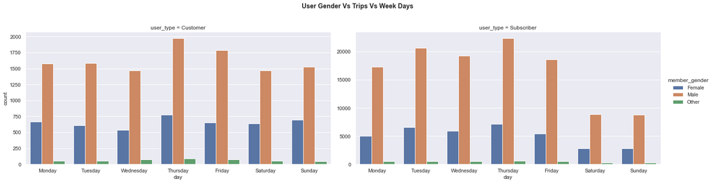

```python
figs = sb.catplot(data=df_new, x='day', col="user_type", hue="member_gender", kind='count', sharey = False, height=5, aspect=2);
figs.fig.suptitle('User Gender Vs Trips Vs Week Days', y=1.1, fontsize=14, fontweight='bold');
```

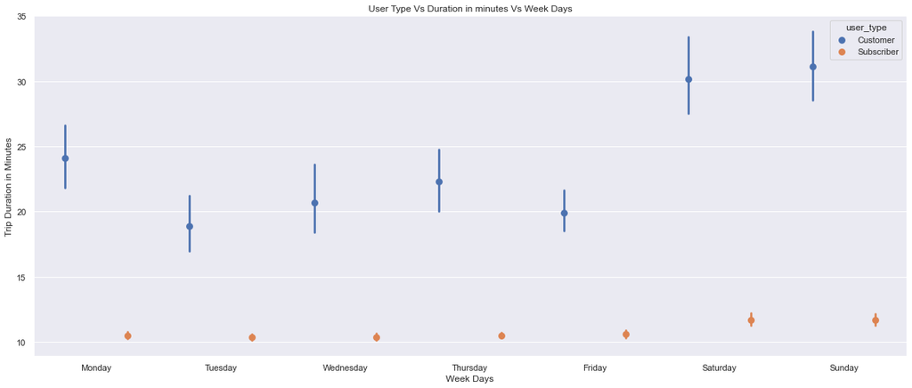

```python
sb.pointplot(data=df_new, x='day', y='duration_min', hue='user_type', dodge=0.5, linestyles="");
plt.title('User Type Vs Duration in minutes Vs Week Days')
plt.xlabel('Week Days');
plt.ylabel('Trip Duration in Minutes');
```

#### I can notice that customers have longer Trips than subscribers. Also Weekend Trips are longer than week days trips.

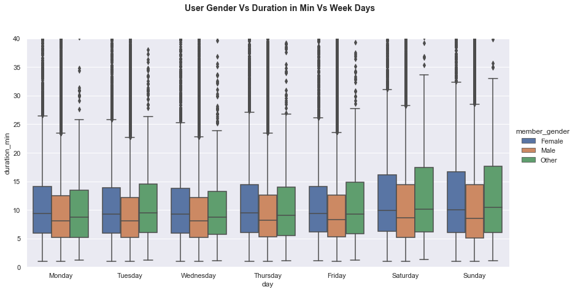

```python
figs1= sb.catplot(data=df_new, x='day', y="duration_min", hue="member_gender", kind="box", height=6, aspect=2)
plt.ylim(0,40);
figs1.fig.suptitle('User Gender Vs Duration in Min Vs Week Days', y=1.1, fontsize=14, fontweight='bold');
```

### Were there any interesting or surprising interactions between features?

I can notice that customers have longer Trips than subscribers. Also Weekend Trips are longer than week days trips.

> At the end of your report, make sure that you export the notebook as an html file from the `File > Download as... > HTML` menu. Make sure you keep track of where the exported file goes, so you can put it in the same folder as this notebook for project submission. Also, make sure you remove all of the quote-formatted guide notes like this one before you finish your report!